# Exploratory Data Analysis

Tyler B. Garner, tbgarner5023@psu.edu

2023-01-26

Exploratory Data Analysis (EDA) is an approach to analyzing and understanding data sets through visual and statistical methods. The goal of EDA is to discover patterns, features, and relationships in the data that can inform further analysis and modeling. It is typically the first step in the data analysis process and is used to gain a preliminary understanding of the data before more formal statistical analysis is performed. Techniques used in EDA include visualization, descriptive statistics, and data cleaning.

## Set-up and load data

```r
source('src/scripts/do_packages.R')

libs <- c('tidyverse', 'corrplot')
do_packages(libs)
```

```
## tidyverse  corrplot
##      TRUE      TRUE
```

```r
kdd <- readRDS('data/interim/kdd.RDS')
```

## Dataset structure and descriptive statistics

The next set of commands will print out information on the dataset’s structure.

```r
dim(kdd)
```

```
## [1] 148517     45
```

```r
str(kdd)
```

```
## tibble [148,517 × 45] (S3: tbl_df/tbl/data.frame)
##  $ Duration                   : num [1:148517] 0 0 0 0 0 0 0 0 0 0 ...
##  $ Protocol.Type              : chr [1:148517] "tcp" "udp" "tcp" "tcp" ...
##  $ Service                    : chr [1:148517] "ftp_data" "other" "private" "http" ...
##  $ Flag                       : chr [1:148517] "SF" "SF" "S0" "SF" ...
##  $ Src.Bytes                  : num [1:148517] 491 146 0 232 199 0 0 0 0 0 ...
##  $ Dst.Bytes                  : num [1:148517] 0 0 0 8153 420 ...
##  $ Land                       : num [1:148517] 0 0 0 0 0 0 0 0 0 0 ...
##  $ Wrong.Fragment             : num [1:148517] 0 0 0 0 0 0 0 0 0 0 ...
##  $ Urgent                     : num [1:148517] 0 0 0 0 0 0 0 0 0 0 ...
##  $ Hot                        : num [1:148517] 0 0 0 0 0 0 0 0 0 0 ...
##  $ Num.Failed.Logins          : num [1:148517] 0 0 0 0 0 0 0 0 0 0 ...
##  $ Logged.In                  : num [1:148517] 0 0 0 1 1 0 0 0 0 0 ...
##  $ Num.Compromised            : num [1:148517] 0 0 0 0 0 0 0 0 0 0 ...
##  $ Root.Shell                 : num [1:148517] 0 0 0 0 0 0 0 0 0 0 ...
```

[output cut: 31 more lines]

The total NSL-KDD data set has 148,517 data points across 43 variables (two of the 45 variables in this data set are created in the set-up script). Notably, there are four character variables that may be more useful re-coded as factors.

To check whether the character variables could be more useful as factors the total number of unique values in each will be calculated.

```r
kdd %>%
  select(where(is.character)) %>%
  apply(2, function(x) length(unique(x)))
```

```
## Protocol.Type       Service          Flag      Subclass
##             3            70            11            40
```

The dataset is much larger than any of these values, which can justify re-coding them to the factor type.

```r
kdd <- kdd %>%
  mutate(across(where(is.character), factor))
```

With these variables re-coded, summary statistics for all of the variables will be generated.

```r
summary(kdd)
```

```
##     Duration       Protocol.Type     Service           Flag         Src.Bytes
##  Min.   :    0.0   icmp:  9334   http    :48191   SF     :89820   Min.   :0.000e+00
##  1st Qu.:    0.0   tcp :121569   private :26627   S0     :36864   1st Qu.:0.000e+00
##  Median :    0.0   udp : 17614   domain_u: 9937   REJ    :15083   Median :4.400e+01
##  Mean   :  276.8                 smtp    : 8247   RSTR   : 3090   Mean   :4.023e+04
##  3rd Qu.:    0.0                 ftp_data: 7711   RSTO   : 2335   3rd Qu.:2.780e+02
##  Max.   :57715.0                 other   : 5197   S1     :  386   Max.   :1.380e+09
##                                  (Other) :42607   (Other):  939
##    Dst.Bytes              Land           Wrong.Fragment        Urgent              Hot
##  Min.   :0.000e+00   Min.   :0.0000000   Min.   :0.00000   Min.   :0.000000   Min.   :  0.0000
##  1st Qu.:0.000e+00   1st Qu.:0.0000000   1st Qu.:0.00000   1st Qu.:0.000000   1st Qu.:  0.0000
##  Median :0.000e+00   Median :0.0000000   Median :0.00000   Median :0.000000   Median :  0.0000
##  Mean   :1.709e+04   Mean   :0.0002155   Mean   :0.02052   Mean   :0.000202   Mean   :  0.1894
##  3rd Qu.:5.710e+02   3rd Qu.:0.0000000   3rd Qu.:0.00000   3rd Qu.:0.000000   3rd Qu.:  0.0000
##  Max.   :1.310e+09   Max.   :1.0000000   Max.   :3.00000   Max.   :3.000000   Max.   :101.0000
##
##  Num.Failed.Logins    Logged.In      Num.Compromised      Root.Shell        Su.Attempted
##  Min.   :0.000000   Min.   :0.0000   Min.   :   0.000   Min.   :0.000000   Min.   :0.0000000
##  1st Qu.:0.000000   1st Qu.:0.0000   1st Qu.:   0.000   1st Qu.:0.000000   1st Qu.:0.0000000
##  Median :0.000000   Median :0.0000   Median :   0.000   Median :0.000000   Median :0.0000000
##  Mean   :0.004323   Mean   :0.4028   Mean   :   0.255   Mean   :0.001508   Mean   :0.0009763
##  3rd Qu.:0.000000   3rd Qu.:1.0000   3rd Qu.:   0.000   3rd Qu.:0.000000   3rd Qu.:0.0000000
##  Max.   :5.000000   Max.   :1.0000   Max.   :7479.000   Max.   :1.000000   Max.   :2.0000000
##
##     Num.Root        Num.File.Creations    Num.Shells       Num.Access.Files   Num.Outbound.Cmds
##  Min.   :   0.000   Min.   :  0.00000   Min.   :0.000000   Min.   :0.000000   Min.   :0
##  1st Qu.:   0.000   1st Qu.:  0.00000   1st Qu.:0.000000   1st Qu.:0.000000   1st Qu.:0
##  Median :   0.000   Median :  0.00000   Median :0.000000   Median :0.000000   Median :0
##  Mean   :   0.274   Mean   :  0.01207   Mean   :0.000525   Mean   :0.004013   Mean   :0
##  3rd Qu.:   0.000   3rd Qu.:  0.00000   3rd Qu.:0.000000   3rd Qu.:0.000000   3rd Qu.:0
##  Max.   :7468.000   Max.   :100.00000   Max.   :5.000000   Max.   :9.000000   Max.   :0
##
##  Is.Hot.Logins      Is.Guest.Login        Count          Srv.Count       Serror.Rate
##  Min.   :0.00e+00   Min.   :0.00000   Min.   :  0.00   Min.   :  0.00   Min.   :0.0000
##  1st Qu.:0.00e+00   1st Qu.:0.00000   1st Qu.:  2.00   1st Qu.:  2.00   1st Qu.:0.0000
##  Median :0.00e+00   Median :0.00000   Median : 13.00   Median :  7.00   Median :0.0000
##  Mean   :8.08e-05   Mean   :0.01231   Mean   : 83.34   Mean   : 28.25   Mean   :0.2569
##  3rd Qu.:0.00e+00   3rd Qu.:0.00000   3rd Qu.:141.00   3rd Qu.: 17.00   3rd Qu.:0.8500
##  Max.   :1.00e+00   Max.   :1.00000   Max.   :511.00   Max.   :511.00   Max.   :1.0000
##
```

[output cut: 25 more lines]

```
##  Min.   :0.0000       Min.   :0.0000           Min.   :0.0000       Min.   :0.0000
##  1st Qu.:0.0000       1st Qu.:0.0000           1st Qu.:0.0000       1st Qu.:0.0000
##  Median :0.0000       Median :0.0000           Median :0.0000       Median :0.0000
##  Mean   :0.2561       Mean   :0.2513           Mean   :0.1362       Mean   :0.1364
##  3rd Qu.:0.6000       3rd Qu.:0.5000           3rd Qu.:0.0000       3rd Qu.:0.0000
##  Max.   :1.0000       Max.   :1.0000           Max.   :1.0000       Max.   :1.0000
##
##       Subclass     Difficulty.Level    Class           Type
##  normal   :77054   Min.   : 0.00    Normal:77054   Attack:71463
##  neptune  :45871   1st Qu.:18.00    DoS   :53387   Normal:77054
##  satan    : 4368   Median :20.00    Probe :14077
##  ipsweep  : 3740   Mean   :19.28    R2L   : 3880
##  smurf    : 3311   3rd Qu.:21.00    U2R   :  119
##  portsweep: 3088   Max.   :21.00
##  (Other)  :11085
```

The total number of normal and connections are about equal. Some of the numeric variables have very large ranges compared to other variables, and many have medians = 0. This could suggeset that there is some right-skew in these variables and that centering and scaling, in addition to transformations, could be useful for modeling. Additionally, there is one variable, *Num.Outbound.Cmds*, that has zero-variance (all observations have the same value) and can be removed.

After removing *Num.Outbound.Cmds*, histograms for the remaining numeric variables will be generated to assess their distributions.

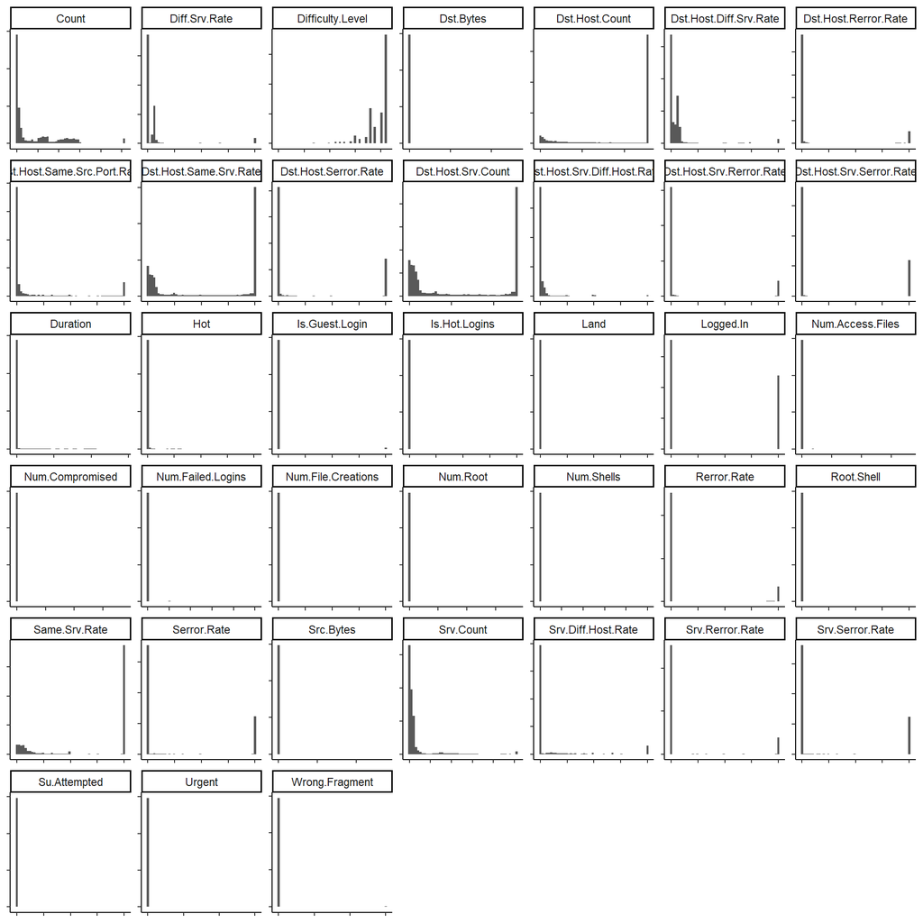

```r
kdd <- kdd %>%
  select(!Num.Outbound.Cmds)

kdd %>%
  select(where(is.numeric)) %>%
  pivot_longer(everything()) %>%
  ggplot(aes(x = value)) +
    geom_histogram(bins = 50) +
    facet_wrap(~ name,
               scales = 'free') +
    labs(x = NULL,
         y = NULL) +
    theme_classic() +
    theme(axis.text = element_blank())
```

From the histograms there are clearly no normally distributed variables. Additionally, while some variables appeared binary from the summary statistics there are clearly a few points in between 0 and 1. Others are still clearly binary, such as *Logged.In*.

## Two-variable statistics

To observe porential relationships between variables a correlogram of the numeric variables will be generated. The *Type* variable, which indicates whether a connection is normal or an intrusion, will also be included. Spearman’s rank correlation will be used as the data are non-normal and include some binary variables.

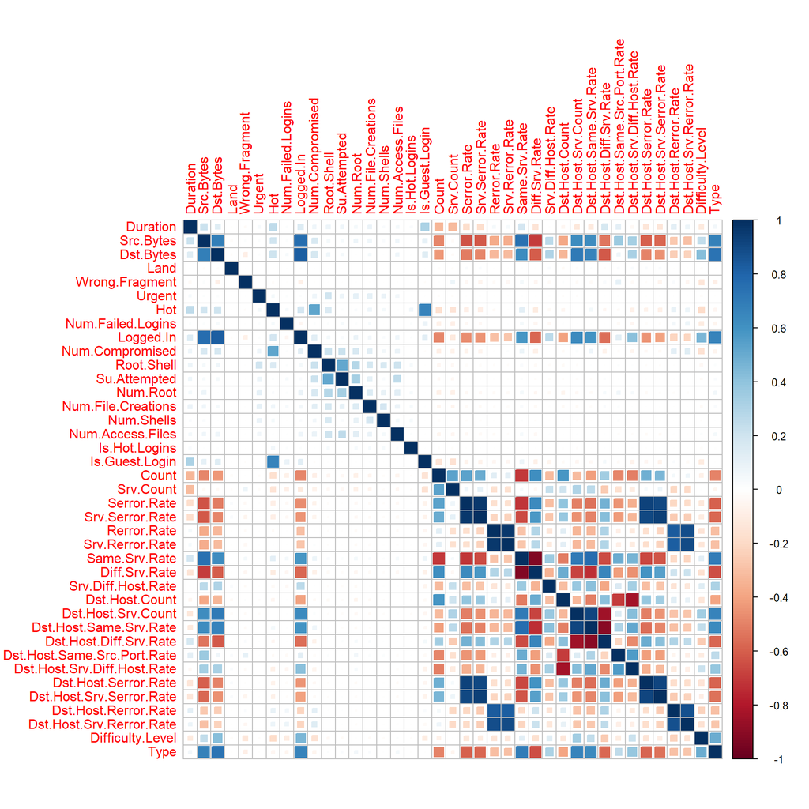

```r
kdd_cors <- kdd %>%
  select(where(is.numeric), Type) %>%
  mutate(across(everything(), ~ as.numeric(.))) %>%
  cor(method = 'spearman')

corrplot(kdd_cors,
         method = 'square')
```

In the correlogram above it is obvious there are some relationships between the variables. In particular *Src.Bytes* and *Dst.Bytes* have a strong relationship together while most of the many “count” and “rate” variables are highly correlated with one another. These variables are also rank-correlated with *Type*, suggesting they could be predictive of attacks.